# 03 Introducción a la estimación de parámetros.

2024-01-17

## Tema 1.2 Estimación Puntual y por Intervalo.

## Tema 1.2.1 Teorema del Límite Central

- Si \(Z\) es el conjunto de \(n\) realizaciones independientes de una variable aleatoria \(X\)
- Con una distribución con desviación estándar finita y no nula.
- Entonces la distribución de los promedios de esas observaciones se aproxima a una distribución normal a medida que \(n\) aumenta.

## Tema 1.2.1 Teorema del Límite Central: Ejemplo (1)

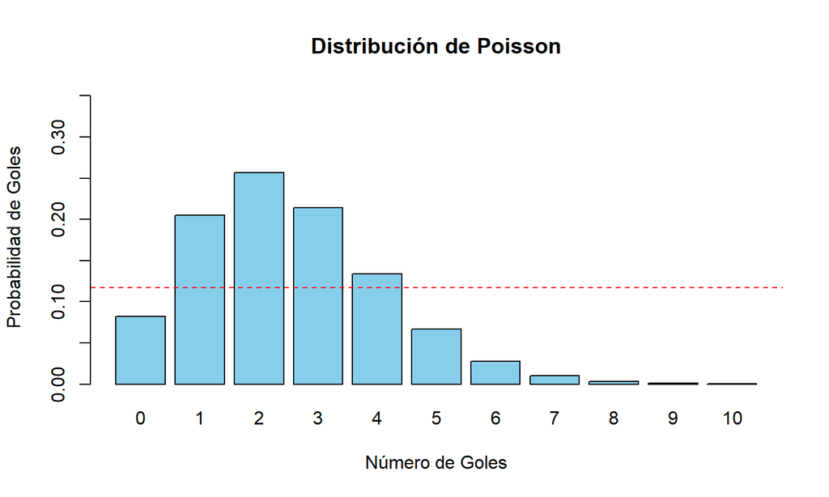

## Tema 1.2.1 Teorema del Límite Central: Ejemplo (2)

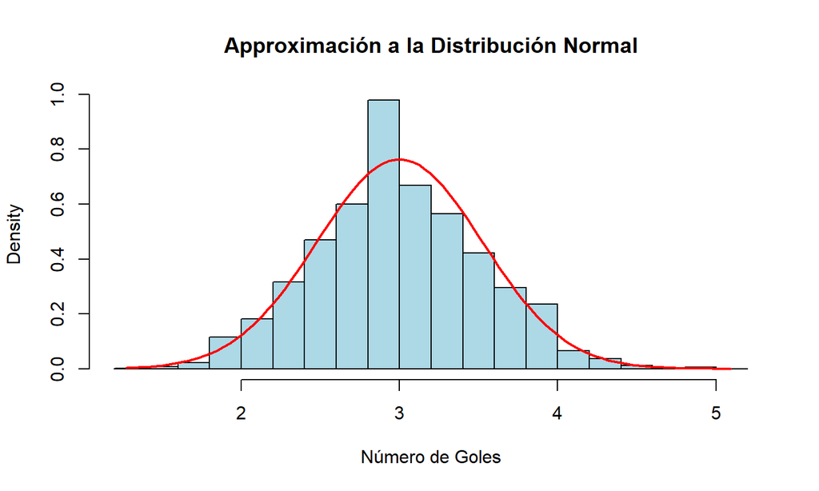

## Tema 1.2.2 Estimación Puntual

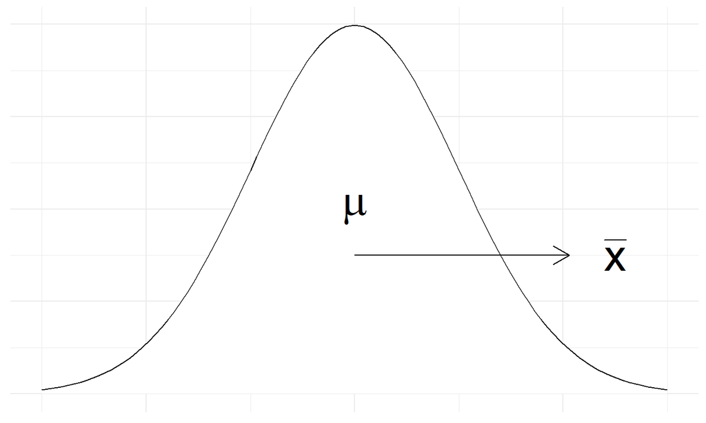

## Tema 1.2.2 Estimación Puntual

- **Un estimador puntual** es el valor muestral de un parámetro poblacional.

| Parámetros Poblacionales | Estimadores Puntuales | Nombre del Parámetro |
| --- | --- | --- |
| \(\mu\) | \(\overline{x}\) | Media |
| \(\sigma^2\) | \(s^2\) | Varianza |
| \(\sigma\) | \(s\) | Desviación estándar |

## Tema 1.2.2 Estimación Puntual

1. Media Muestral \[ \overline{x} = \frac{1}{n} \sum_{i=1}^{n} x_i \]
2. Varianza Muestral \[s^2 = \frac{1}{n-1} \sum_{i=1}^{n} (x_i - \overline{x})^2\]
3. Desviación Estándar Muestral

\[s = \sqrt{s^2}\]

## Tema 1.2.2 Estimación Puntual, Ejemplo

Supón que tienes datos de 10 días de la temperatura máxima en Mérida durante enero:

\(\begin{align*} &[32.21, 27.21, 25.83, 28.13, 33.89, \\ &\quad 26.01, 26.11, 28.73, 28.72, 33.89] \end{align*}\)

- Calcula un estimador puntual de la media, la varianza y la desviación estandar.

## Tema 1.2.2 Estimación Puntual: media

- Media \[ \overline{x} = \frac{1}{10} \left( 32.21 + 27.21 + \ldots + 28.72 + 33.89 \right) \]

Calculando el resultado:

\[ \overline{x} = \frac{290.73}{10} \]

\[ \overline{x} = 29.073 \]

## Tema 1.2.2 Estimación Puntual, varianza y d.s

- Varianza

\[\begin{align*} s^2 &= \frac{1}{9} \left( (32.21 - 29.07)^2 + (27.21 - 29.07)^2 + \right. \\ &\quad \left. \ldots + (33.89 - 29.07)^2 \right) \end{align*}\]

\[ s^2 = \frac{1}{9} \times 89.528 \]

\[ s^2 = 9.95 \]

- Desviación Estándar: \[ s = \sqrt{s^2} = 3.15 \]

## Tema 1.2.3 Estimación Puntual y Estimación Ponderada

- Ojo, la estimación puntual aproxima parámetros en base a una muestra.
- El valor esperado y su correspondiente varianza son medidas ponderadas.
- Las medidas ponderadas se consideran parámetros poblacionales.
- Usamos **estimadores puntuales** cuando se busca un único valor representativo de la muestra.
- Usamos **medidas ponderas** cuando se analiza la relación entre observaciones y probabilidades.

## Tema 1.2.4 Distribucion Normal: Estimación de probabilidad

- Paso 1: Localizar el valor de \(\overline{x}\) alrededor de la media \(\mu\), redondear a 2 decimales.

\[ Z = \frac{\overline{x} - \mu}{\sigma/\sqrt{n}} \]

- Paso 2: usar tablas de probabilidad para localizar el valor(es) \(Z\).
- Paso 3: Graficar la probabilidad.
- Paso 4: Calcular la probabilidad correspondiente.

## Tema 1.2.4 Distribucion Normal: Estimación de probabilidad

Hay tres casos:

- Probabilidad de que \(X\) sea mayor o igual a un punto muestral.

\[P(X \geq x)\]

- Probabilidad de que \(X\) sea menor o igual a un punto muestral.

\[P(X \leq X)\]

- Probabilidad de que \(X\) esté entre dos puntos muestrales.

\[P(x_1 \leq X \leq x_2 )\]

## Tema 1.2.4 Distribución Normal: Estimación de probabilidad, Ejercicio (1)

Supongamos que tenemos datos de 10 días de la temperatura máxima en Mérida durante enero:

\(\begin{align*} &[32.21, 27.21, 25.83, 28.13, 33.89, \\ &\quad 26.01, 26.11, 28.73, 28.72, 33.89] \end{align*}\)

- Calcula un estimador puntual de la media y de la desviación estándar.
- Estima la probabilidad de que la temperatura máxima en enero sea mayor o igual a 31 grados cent.

## Tema 1.2.4 Distribución Normal: Estimación de probabilidad, Ejercicio (1/2)

- Media puntual: \[ \overline{x} = 29.073 \]
- Desviación estándar puntual: \[ s = \sqrt{s^2} = 3.15 \]
- El z-score: \[ Z = \frac{31 - 29.073}{3.15/\sqrt{10}}=1.93 \]

## Tema 1.2.4 Distribución Normal: Estimación de probabilidad, Ejercicio (1/2)

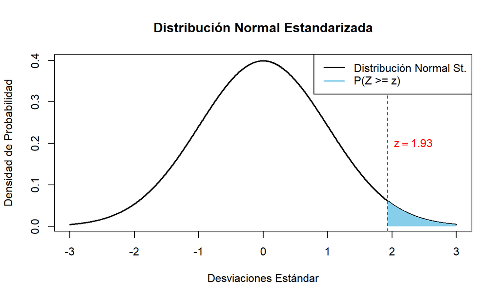

## Tema 1.2.4 Distribución Normal: Estimación de probabilidad, Ejercicio (1/3)

\(P(X\geq 31)= P(Z > 1.93)= 0.0268 = 2.68\%\)

|  | 0.00 | 0.01 | 0.02 | 0.03 |
| --- | --- | --- | --- | --- |
| 1.80 | 0.0359 | 0.0351 | 0.0344 | 0.0336 |
| 1.90 | 0.0287 | 0.0281 | 0.0274 | 0.0268 |
| 2.0 | 0.0228 | 0.0222 | 0.0217 | 0.0212 |

## Tema 1.2.4 Distribución Normal: Estimación de probabilidad, Ejercicio (2/1)

\[P(X\leq 31)= P(Z < 1.93)\]

## Tema 1.2.4 Distribución Normal: Estimación de probabilidad, Ejercicio (2/2)

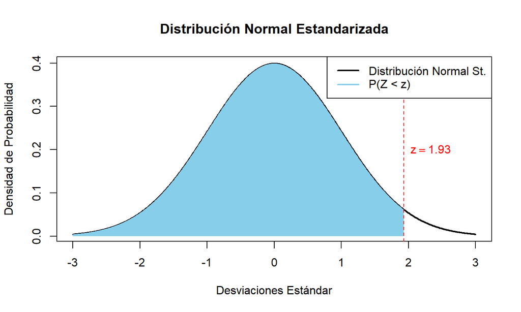

## Tema 1.2.4 Distribución Normal: Estimación de probabilidad, Ejercicio (2/3)

La probabilidad de que la temepratura sea menor a 31 grados:

\[P(X\leq 31)= P(Z < 1.93)= 1 - 0.0268 = 97.32\%\]

## Tema 1.2.4 Distribución Normal: Estimación de probabilidad, Ejercicio (3/1)

- Del ejercicio anterior estima la probabilidad de que la temperatura este entre 28 y 31 grados

\[P(28 \leq X \leq 31)= P(z_1 < Z < z_2)\]

- Calculamos el z-score de 28 grados:

\[ Z = \frac{28 - 29.073}{3.15/\sqrt{10}}=-1.08 \]

## Tema 1.2.4 Distribución Normal: Estimación de probabilidad, Ejercicio (3/2)

- Buscamos el valor de \(P(Z < -1.08)\)

|  | 0.05 | 0.06 | 0.07 | 0.08 |
| --- | --- | --- | --- | --- |
| 0.9 | 0.1711 | 0.1685 | 0.1660 | 0.1635 |
| 1 | 0.1469 | 0.1446 | 0.1423 | 0.1401 |
| 1.1 | 0.1251 | 0.1230 | 0.1210 | 0.1190 |

## Tema 1.2.4 Distribución Normal: Estimación de probabilidad, Ejercicio (3/3)

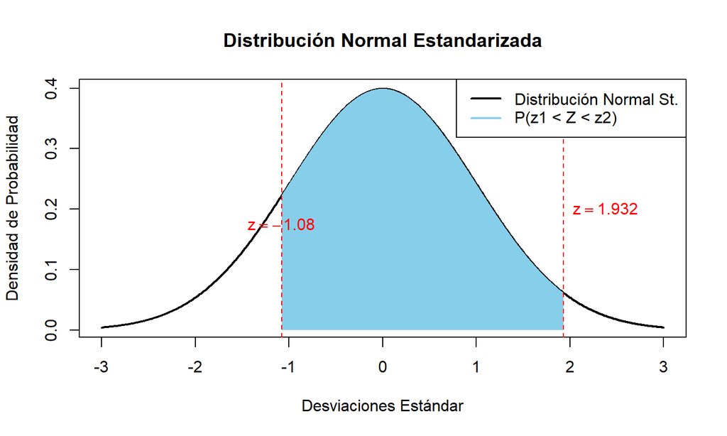

## Tema 1.2.4 Distribución Normal: Estimación de probabilidad, Ejercicio (3/4)

- Menor a 28 grados, \(P(X \leq 28)\): \[P(Z < -1.08)= 0.1401 = 14.01\%\]
- Mayor a 31 grados \(P(X \geq 31)\):

\[P(Z > 1.93)= 0.0268 = 2.68\%\]

Ahora podemos calcular la probabilidad de que la temperatura este entre 28 y 31 grados:

\[P(28 \leq X \leq 31)= 1 - P(Z > 1.93) - P(Z < -1.08) \]

## Tema 1.2.4 Distribución Normal: Estimación de probabilidad, Ejercicio (3/5)

Sustituyendo: \[P(28 \leq X \leq 31)= 1 - 0.0268 - 0.1401=0.8331= 83.31 \%\]

## Tema 1.2.5 Distribución Normal: Estimación por intervalo, Ejercicio (4/1)

Recordemos del ejercico anterior:

- Media puntual \[ \overline{x} = 29.073 \]
- Desviación estándar puntual: \[ s = \sqrt{s^2} = 3.15 \]

Calcula un intervalo de probabilidad del \(95\%\) para la media poblacional (\(\mu\)), utilizando la media de la muestra (\(\overline{X}\)).

## Tema 1.2.5 Distribución Normal: Estimación por intervalo, Ejercicio (4/1)

Formula general para el cómputo de intervalos de confianza: \[\overline{X} \pm Z \times \frac{s}{\sqrt{n}}\]

- Substituyendo \[ [29.073 -1.96*0.996, 29.073+1.96*0.996] \]
- El intervalo de confianza del \(95\%\) de que la media este lo suficiente cerca de \(\mu\)

\[ [27.12, 31.03] \]

## Tema 1.2.5 Distribución Normal: Estimación por intervalo, Ejercicio (4/2)

- Calcula un intervalo de probabilidad del \(99\%\) para la media poblacional (\(\mu\)), utilizando la media de la muestra (\(\overline{X}\)).
- Substituyendo \[ [29.073 -2.56*0.996, 29.073+2.56*0.996] \]
- El intervalo de confianza del \(99\%\) de que la media se encuentre lo suficiente cerca de \(\mu\) \[ [26.52, 31.62] \]

## Revisión

## Revisión

```
## Versión: 22/01/2024
```

## Bibliografía

## Bibliografía

- Smith, G. (2015). *Essential statistics, regression, and econometrics.*
- Stock, J. H., & Watson, M. W. (2020). Introduction to econometrics. Pearson.
- Ross, S. M. (2014). A first course in probability.
- Lipschutz, S. (2000). Schaum’s outline of probability. McGraw Hill Professional.
- https://espanol.libretexts.org/Estadisticas/